# Risk Factor Analysis

## Outcome Variable

**Outcome Variable:** stunted

## Predictor Variables

**Intervention Variable:** predfeed3

**Adjustment Set:**

- arm
- sex
- month
- brthmon
- W_mage
- meducyrs
- feducyrs
- hhwealth_quart
- hfoodsec
- W_mhtcm
- vagbrth
- W_gagebrth
- W_birthwt
- W_birthlen
- W_nrooms
- W_nchldlt5
- W_parity
- impfloor
- impsan
- safeh20
- delta_W_mage
- delta_meducyrs
- delta_feducyrs
- delta_hhwealth_quart
- delta_hfoodsec
- delta_W_mhtcm
- delta_vagbrth
- delta_W_gagebrth
- delta_W_birthwt
- delta_W_birthlen
- delta_W_nrooms
- delta_W_nchldlt5
- delta_W_parity
- delta_impfloor
- delta_impsan
- delta_safeh20

## Stratifying Variables

The analysis was stratified on these variable(s):

- agecat
- studyid
- country

## Data Summary

| agecat | studyid | country | predfeed3 | stunted | n_cell | n |
| --- | --- | --- | --- | --- | --- | --- |
| Birth | ki0047075b-MAL-ED | BANGLADESH | 0 | 0 | 30 | 240 |
| Birth | ki0047075b-MAL-ED | BANGLADESH | 0 | 1 | 5 | 240 |
| Birth | ki0047075b-MAL-ED | BANGLADESH | 1 | 0 | 169 | 240 |
| Birth | ki0047075b-MAL-ED | BANGLADESH | 1 | 1 | 36 | 240 |
| Birth | ki0047075b-MAL-ED | BRAZIL | 0 | 0 | 73 | 185 |
| Birth | ki0047075b-MAL-ED | BRAZIL | 0 | 1 | 11 | 185 |
| Birth | ki0047075b-MAL-ED | BRAZIL | 1 | 0 | 93 | 185 |
| Birth | ki0047075b-MAL-ED | BRAZIL | 1 | 1 | 8 | 185 |
| Birth | ki0047075b-MAL-ED | INDIA | 0 | 0 | 35 | 196 |
| Birth | ki0047075b-MAL-ED | INDIA | 0 | 1 | 9 | 196 |
| Birth | ki0047075b-MAL-ED | INDIA | 1 | 0 | 130 | 196 |
| Birth | ki0047075b-MAL-ED | INDIA | 1 | 1 | 22 | 196 |
| Birth | ki0047075b-MAL-ED | NEPAL | 0 | 0 | 62 | 171 |
| Birth | ki0047075b-MAL-ED | NEPAL | 0 | 1 | 10 | 171 |
| Birth | ki0047075b-MAL-ED | NEPAL | 1 | 0 | 91 | 171 |
| Birth | ki0047075b-MAL-ED | NEPAL | 1 | 1 | 8 | 171 |
| Birth | ki0047075b-MAL-ED | PERU | 0 | 0 | 80 | 272 |
| Birth | ki0047075b-MAL-ED | PERU | 0 | 1 | 9 | 272 |
| Birth | ki0047075b-MAL-ED | PERU | 1 | 0 | 160 | 272 |
| Birth | ki0047075b-MAL-ED | PERU | 1 | 1 | 23 | 272 |
| Birth | ki0047075b-MAL-ED | SOUTH AFRICA | 0 | 0 | 129 | 233 |
| Birth | ki0047075b-MAL-ED | SOUTH AFRICA | 0 | 1 | 17 | 233 |
| Birth | ki0047075b-MAL-ED | SOUTH AFRICA | 1 | 0 | 80 | 233 |
| Birth | ki0047075b-MAL-ED | SOUTH AFRICA | 1 | 1 | 7 | 233 |
| Birth | ki0047075b-MAL-ED | TANZANIA, UNITED REPUBLIC OF | 0 | 0 | 56 | 119 |
| Birth | ki0047075b-MAL-ED | TANZANIA, UNITED REPUBLIC OF | 0 | 1 | 13 | 119 |
| Birth | ki0047075b-MAL-ED | TANZANIA, UNITED REPUBLIC OF | 1 | 0 | 45 | 119 |
| Birth | ki0047075b-MAL-ED | TANZANIA, UNITED REPUBLIC OF | 1 | 1 | 5 | 119 |
| Birth | ki1000109-EE | PAKISTAN | 0 | 0 | 0 | 4 |
| Birth | ki1000109-EE | PAKISTAN | 0 | 1 | 0 | 4 |

[output cut: 94 more lines]

The following strata were considered:

- agecat: 24 months, studyid: ki0047075b-MAL-ED, country: BANGLADESH
- agecat: 24 months, studyid: ki0047075b-MAL-ED, country: BRAZIL
- agecat: 24 months, studyid: ki0047075b-MAL-ED, country: INDIA
- agecat: 24 months, studyid: ki0047075b-MAL-ED, country: NEPAL
- agecat: 24 months, studyid: ki0047075b-MAL-ED, country: PERU
- agecat: 24 months, studyid: ki0047075b-MAL-ED, country: SOUTH AFRICA
- agecat: 24 months, studyid: ki0047075b-MAL-ED, country: TANZANIA, UNITED REPUBLIC OF
- agecat: 24 months, studyid: ki1113344-GMS-Nepal, country: NEPAL
- agecat: 24 months, studyid: kiGH5241-JiVitA-3, country: BANGLADESH
- agecat: 24 months, studyid: kiGH5241-JiVitA-4, country: BANGLADESH
- agecat: 6 months, studyid: ki0047075b-MAL-ED, country: BANGLADESH
- agecat: 6 months, studyid: ki0047075b-MAL-ED, country: BRAZIL
- agecat: 6 months, studyid: ki0047075b-MAL-ED, country: INDIA
- agecat: 6 months, studyid: ki0047075b-MAL-ED, country: NEPAL
- agecat: 6 months, studyid: ki0047075b-MAL-ED, country: PERU
- agecat: 6 months, studyid: ki0047075b-MAL-ED, country: SOUTH AFRICA
- agecat: 6 months, studyid: ki0047075b-MAL-ED, country: TANZANIA, UNITED REPUBLIC OF
- agecat: 6 months, studyid: ki1000109-EE, country: PAKISTAN
- agecat: 6 months, studyid: ki1113344-GMS-Nepal, country: NEPAL
- agecat: 6 months, studyid: kiGH5241-JiVitA-3, country: BANGLADESH
- agecat: 6 months, studyid: kiGH5241-JiVitA-4, country: BANGLADESH
- agecat: Birth, studyid: ki0047075b-MAL-ED, country: BANGLADESH
- agecat: Birth, studyid: ki0047075b-MAL-ED, country: BRAZIL
- agecat: Birth, studyid: ki0047075b-MAL-ED, country: INDIA
- agecat: Birth, studyid: ki0047075b-MAL-ED, country: NEPAL
- agecat: Birth, studyid: ki0047075b-MAL-ED, country: PERU
- agecat: Birth, studyid: ki0047075b-MAL-ED, country: SOUTH AFRICA
- agecat: Birth, studyid: ki0047075b-MAL-ED, country: TANZANIA, UNITED REPUBLIC OF
- agecat: Birth, studyid: ki1000109-EE, country: PAKISTAN
- agecat: Birth, studyid: kiGH5241-JiVitA-3, country: BANGLADESH
- agecat: Birth, studyid: kiGH5241-JiVitA-4, country: BANGLADESH

### Dropped Strata

Some strata were dropped due to rare outcomes:

- agecat: Birth, studyid: ki1000109-EE, country: PAKISTAN
- agecat: Birth, studyid: kiGH5241-JiVitA-4, country: BANGLADESH
- agecat: 6 months, studyid: ki0047075b-MAL-ED, country: BRAZIL
- agecat: 24 months, studyid: ki0047075b-MAL-ED, country: BRAZIL

## Methods Detail

We’re interested in the causal parameters $E[Y_a]$ for all values of $a \in \mathcal{A}$. These parameters represent the mean outcome if, possibly contrary to fact, we intervened to set all units to have $A=a$. Under the randomization and positivity assumptions, these are identified by the statistical parameters $\psi_a=E_W[E_{Y|A,W}(Y|A=a,W)]$. In addition, we’re interested in the mean of $Y$, $E[Y]$ under no intervention (the observed mean). We will estimate these parameters by using SuperLearner to fit the relevant likelihood factors – $E_{Y|A,W}(Y|A=a,W)$ and $p(A=a|W)$, and then updating our likelihood fit using a joint TMLE.

For unadjusted analyses ($W=\{\}$), initial likelihoods were estimated using Lrnr_glm to estimate the simple $E(Y|A)$ and Lrnr_mean to estimate $p(A)$. For adjusted analyses, a small library containing Lrnr_glmnet, Lrnr_xgboost, and Lrnr_mean was used.

Having estimated these parameters, we will then use the delta method to estimate relative risks and attributable risks relative to a prespecified baseline level of $A$.

# Results Detail

## Results Plots

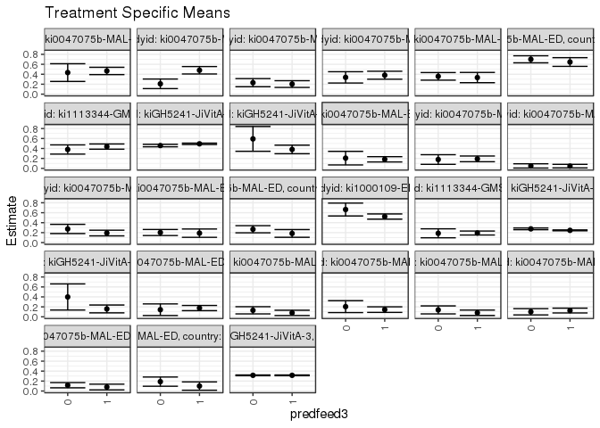

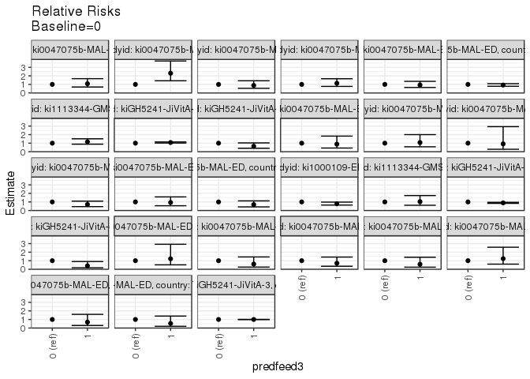

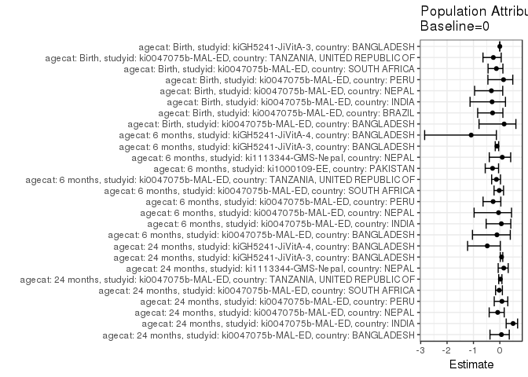

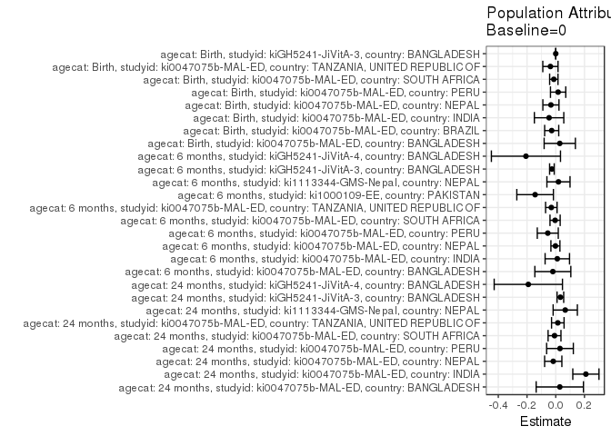

## Results Table

### Parameter: TSM

| agecat | studyid | country | intervention_level | baseline_level | estimate | ci_lower | ci_upper |
| --- | --- | --- | --- | --- | --- | --- | --- |
| Birth | ki0047075b-MAL-ED | BANGLADESH | 0 | NA | 0.1428571 | 0.0266860 | 0.2590283 |
| Birth | ki0047075b-MAL-ED | BANGLADESH | 1 | NA | 0.1756098 | 0.1234160 | 0.2278035 |
| Birth | ki0047075b-MAL-ED | BRAZIL | 0 | NA | 0.1309524 | 0.0586148 | 0.2032899 |
| Birth | ki0047075b-MAL-ED | BRAZIL | 1 | NA | 0.0792079 | 0.0263963 | 0.1320195 |
| Birth | ki0047075b-MAL-ED | INDIA | 0 | NA | 0.2045455 | 0.0850545 | 0.3240364 |
| Birth | ki0047075b-MAL-ED | INDIA | 1 | NA | 0.1447368 | 0.0886609 | 0.2008128 |
| Birth | ki0047075b-MAL-ED | NEPAL | 0 | NA | 0.1388889 | 0.0587730 | 0.2190048 |
| Birth | ki0047075b-MAL-ED | NEPAL | 1 | NA | 0.0808081 | 0.0269644 | 0.1346517 |
| Birth | ki0047075b-MAL-ED | PERU | 0 | NA | 0.1011236 | 0.0383714 | 0.1638758 |
| Birth | ki0047075b-MAL-ED | PERU | 1 | NA | 0.1256831 | 0.0775664 | 0.1737997 |
| Birth | ki0047075b-MAL-ED | SOUTH AFRICA | 0 | NA | 0.1164384 | 0.0642982 | 0.1685785 |
| Birth | ki0047075b-MAL-ED | SOUTH AFRICA | 1 | NA | 0.0804598 | 0.0231805 | 0.1377390 |
| Birth | ki0047075b-MAL-ED | TANZANIA, UNITED REPUBLIC OF | 0 | NA | 0.1884058 | 0.0957500 | 0.2810616 |
| Birth | ki0047075b-MAL-ED | TANZANIA, UNITED REPUBLIC OF | 1 | NA | 0.1000000 | 0.0164942 | 0.1835058 |
| Birth | kiGH5241-JiVitA-3 | BANGLADESH | 0 | NA | 0.3155815 | 0.3080123 | 0.3231506 |
| Birth | kiGH5241-JiVitA-3 | BANGLADESH | 1 | NA | 0.3156006 | 0.3080302 | 0.3231710 |
| 6 months | ki0047075b-MAL-ED | BANGLADESH | 0 | NA | 0.2058824 | 0.0696818 | 0.3420829 |
| 6 months | ki0047075b-MAL-ED | BANGLADESH | 1 | NA | 0.1822660 | 0.1290457 | 0.2354863 |
| 6 months | ki0047075b-MAL-ED | INDIA | 0 | NA | 0.1779178 | 0.0813357 | 0.2744999 |
| 6 months | ki0047075b-MAL-ED | INDIA | 1 | NA | 0.1909854 | 0.1334065 | 0.2485644 |
| 6 months | ki0047075b-MAL-ED | NEPAL | 0 | NA | 0.0495050 | 0.0071094 | 0.0919005 |
| 6 months | ki0047075b-MAL-ED | NEPAL | 1 | NA | 0.0454545 | 0.0098437 | 0.0810654 |
| 6 months | ki0047075b-MAL-ED | PERU | 0 | NA | 0.2740331 | 0.1814746 | 0.3665917 |
| 6 months | ki0047075b-MAL-ED | PERU | 1 | NA | 0.1918553 | 0.1350284 | 0.2486823 |
| 6 months | ki0047075b-MAL-ED | SOUTH AFRICA | 0 | NA | 0.2021883 | 0.1414306 | 0.2629460 |
| 6 months | ki0047075b-MAL-ED | SOUTH AFRICA | 1 | NA | 0.1894608 | 0.1060888 | 0.2728328 |
| 6 months | ki0047075b-MAL-ED | TANZANIA, UNITED REPUBLIC OF | 0 | NA | 0.2682476 | 0.1967270 | 0.3397683 |
| 6 months | ki0047075b-MAL-ED | TANZANIA, UNITED REPUBLIC OF | 1 | NA | 0.1837535 | 0.1061426 | 0.2613643 |
| 6 months | ki1000109-EE | PAKISTAN | 0 | NA | 0.6638782 | 0.5347879 | 0.7929684 |
| 6 months | ki1000109-EE | PAKISTAN | 1 | NA | 0.5230099 | 0.4705529 | 0.5754670 |
| 6 months | ki1113344-GMS-Nepal | NEPAL | 0 | NA | 0.1863087 | 0.0964464 | 0.2761710 |
| 6 months | ki1113344-GMS-Nepal | NEPAL | 1 | NA | 0.1924649 | 0.1525894 | 0.2323404 |
| 6 months | kiGH5241-JiVitA-3 | BANGLADESH | 0 | NA | 0.2756465 | 0.2581245 | 0.2931685 |
| 6 months | kiGH5241-JiVitA-3 | BANGLADESH | 1 | NA | 0.2458725 | 0.2374699 | 0.2542751 |
| 6 months | kiGH5241-JiVitA-4 | BANGLADESH | 0 | NA | 0.3985530 | 0.1365089 | 0.6605970 |
| 6 months | kiGH5241-JiVitA-4 | BANGLADESH | 1 | NA | 0.1581201 | 0.0794074 | 0.2368329 |
| 24 months | ki0047075b-MAL-ED | BANGLADESH | 0 | NA | 0.4333333 | 0.2555836 | 0.6110830 |
| 24 months | ki0047075b-MAL-ED | BANGLADESH | 1 | NA | 0.4662921 | 0.3928297 | 0.5397546 |
| 24 months | ki0047075b-MAL-ED | INDIA | 0 | NA | 0.2078993 | 0.1118058 | 0.3039928 |
| 24 months | ki0047075b-MAL-ED | INDIA | 1 | NA | 0.4798676 | 0.4053073 | 0.5544279 |
| 24 months | ki0047075b-MAL-ED | NEPAL | 0 | NA | 0.2307740 | 0.1491075 | 0.3124406 |
| 24 months | ki0047075b-MAL-ED | NEPAL | 1 | NA | 0.2030187 | 0.1354084 | 0.2706291 |
| 24 months | ki0047075b-MAL-ED | PERU | 0 | NA | 0.3373374 | 0.2238568 | 0.4508179 |
| 24 months | ki0047075b-MAL-ED | PERU | 1 | NA | 0.3803817 | 0.3004781 | 0.4602853 |
| 24 months | ki0047075b-MAL-ED | SOUTH AFRICA | 0 | NA | 0.3576159 | 0.2810027 | 0.4342291 |
| 24 months | ki0047075b-MAL-ED | SOUTH AFRICA | 1 | NA | 0.3333333 | 0.2304518 | 0.4362148 |
| 24 months | ki0047075b-MAL-ED | TANZANIA, UNITED REPUBLIC OF | 0 | NA | 0.6999200 | 0.6291174 | 0.7707226 |
| 24 months | ki0047075b-MAL-ED | TANZANIA, UNITED REPUBLIC OF | 1 | NA | 0.6454377 | 0.5579959 | 0.7328794 |
| 24 months | ki1113344-GMS-Nepal | NEPAL | 0 | NA | 0.3793884 | 0.2868314 | 0.4719454 |
| 24 months | ki1113344-GMS-Nepal | NEPAL | 1 | NA | 0.4376041 | 0.3852515 | 0.4899566 |
| 24 months | kiGH5241-JiVitA-3 | BANGLADESH | 0 | NA | 0.4582300 | 0.4335933 | 0.4828668 |
| 24 months | kiGH5241-JiVitA-3 | BANGLADESH | 1 | NA | 0.4931827 | 0.4793716 | 0.5069939 |
| 24 months | kiGH5241-JiVitA-4 | BANGLADESH | 0 | NA | 0.5922368 | 0.3433799 | 0.8410937 |
| 24 months | kiGH5241-JiVitA-4 | BANGLADESH | 1 | NA | 0.3801769 | 0.2942174 | 0.4661363 |

### Parameter: E(Y)

| agecat | studyid | country | intervention_level | baseline_level | estimate | ci_lower | ci_upper |
| --- | --- | --- | --- | --- | --- | --- | --- |
| Birth | ki0047075b-MAL-ED | BANGLADESH | NA | NA | 0.1708333 | 0.1231182 | 0.2185485 |
| Birth | ki0047075b-MAL-ED | BRAZIL | NA | NA | 0.1027027 | 0.0588397 | 0.1465657 |
| Birth | ki0047075b-MAL-ED | INDIA | NA | NA | 0.1581633 | 0.1069482 | 0.2093783 |
| Birth | ki0047075b-MAL-ED | NEPAL | NA | NA | 0.1052632 | 0.0591304 | 0.1513959 |
| Birth | ki0047075b-MAL-ED | PERU | NA | NA | 0.1176471 | 0.0792874 | 0.1560068 |
| Birth | ki0047075b-MAL-ED | SOUTH AFRICA | NA | NA | 0.1030043 | 0.0638908 | 0.1421178 |
| Birth | ki0047075b-MAL-ED | TANZANIA, UNITED REPUBLIC OF | NA | NA | 0.1512605 | 0.0866122 | 0.2159088 |
| Birth | kiGH5241-JiVitA-3 | BANGLADESH | NA | NA | 0.3156066 | 0.3080361 | 0.3231771 |
| 6 months | ki0047075b-MAL-ED | BANGLADESH | NA | NA | 0.1856540 | 0.1360463 | 0.2352617 |
| 6 months | ki0047075b-MAL-ED | INDIA | NA | NA | 0.1888412 | 0.1384789 | 0.2392035 |
| 6 months | ki0047075b-MAL-ED | NEPAL | NA | NA | 0.0472103 | 0.0199192 | 0.0745014 |
| 6 months | ki0047075b-MAL-ED | PERU | NA | NA | 0.2185185 | 0.1691358 | 0.2679013 |
| 6 months | ki0047075b-MAL-ED | SOUTH AFRICA | NA | NA | 0.1975806 | 0.1479246 | 0.2472367 |
| 6 months | ki0047075b-MAL-ED | TANZANIA, UNITED REPUBLIC OF | NA | NA | 0.2375000 | 0.1835488 | 0.2914512 |
| 6 months | ki1000109-EE | PAKISTAN | NA | NA | 0.5202156 | 0.4693105 | 0.5711208 |
| 6 months | ki1113344-GMS-Nepal | NEPAL | NA | NA | 0.2052402 | 0.1682114 | 0.2422689 |
| 6 months | kiGH5241-JiVitA-3 | BANGLADESH | NA | NA | 0.2489405 | 0.2407278 | 0.2571531 |
| 6 months | kiGH5241-JiVitA-4 | BANGLADESH | NA | NA | 0.1910112 | 0.1139350 | 0.2680874 |
| 24 months | ki0047075b-MAL-ED | BANGLADESH | NA | NA | 0.4615385 | 0.3936268 | 0.5294501 |
| 24 months | ki0047075b-MAL-ED | INDIA | NA | NA | 0.4177778 | 0.3531914 | 0.4823642 |
| 24 months | ki0047075b-MAL-ED | NEPAL | NA | NA | 0.2133333 | 0.1596859 | 0.2669808 |
| 24 months | ki0047075b-MAL-ED | PERU | NA | NA | 0.3668342 | 0.2997053 | 0.4339630 |
| 24 months | ki0047075b-MAL-ED | SOUTH AFRICA | NA | NA | 0.3491379 | 0.2876648 | 0.4106110 |
| 24 months | ki0047075b-MAL-ED | TANZANIA, UNITED REPUBLIC OF | NA | NA | 0.7142857 | 0.6530398 | 0.7755316 |
| 24 months | ki1113344-GMS-Nepal | NEPAL | NA | NA | 0.4455446 | 0.3970186 | 0.4940706 |
| 24 months | kiGH5241-JiVitA-3 | BANGLADESH | NA | NA | 0.4904688 | 0.4770397 | 0.5038978 |
| 24 months | kiGH5241-JiVitA-4 | BANGLADESH | NA | NA | 0.4013158 | 0.3195309 | 0.4831007 |

### Parameter: RR

| agecat | studyid | country | intervention_level | baseline_level | estimate | ci_lower | ci_upper |
| --- | --- | --- | --- | --- | --- | --- | --- |
| Birth | ki0047075b-MAL-ED | BANGLADESH | 0 | 0 | 1.0000000 | 1.0000000 | 1.0000000 |
| Birth | ki0047075b-MAL-ED | BANGLADESH | 1 | 0 | 1.2292683 | 0.5171661 | 2.9218866 |
| Birth | ki0047075b-MAL-ED | BRAZIL | 0 | 0 | 1.0000000 | 1.0000000 | 1.0000000 |
| Birth | ki0047075b-MAL-ED | BRAZIL | 1 | 0 | 0.6048605 | 0.2544616 | 1.4377657 |
| Birth | ki0047075b-MAL-ED | INDIA | 0 | 0 | 1.0000000 | 1.0000000 | 1.0000000 |
| Birth | ki0047075b-MAL-ED | INDIA | 1 | 0 | 0.7076023 | 0.3510418 | 1.4263291 |
| Birth | ki0047075b-MAL-ED | NEPAL | 0 | 0 | 1.0000000 | 1.0000000 | 1.0000000 |
| Birth | ki0047075b-MAL-ED | NEPAL | 1 | 0 | 0.5818182 | 0.2410114 | 1.4045495 |
| Birth | ki0047075b-MAL-ED | PERU | 0 | 0 | 1.0000000 | 1.0000000 | 1.0000000 |
| Birth | ki0047075b-MAL-ED | PERU | 1 | 0 | 1.2428658 | 0.5994618 | 2.5768370 |
| Birth | ki0047075b-MAL-ED | SOUTH AFRICA | 0 | 0 | 1.0000000 | 1.0000000 | 1.0000000 |
| Birth | ki0047075b-MAL-ED | SOUTH AFRICA | 1 | 0 | 0.6910074 | 0.2980105 | 1.6022631 |
| Birth | ki0047075b-MAL-ED | TANZANIA, UNITED REPUBLIC OF | 0 | 0 | 1.0000000 | 1.0000000 | 1.0000000 |
| Birth | ki0047075b-MAL-ED | TANZANIA, UNITED REPUBLIC OF | 1 | 0 | 0.5307692 | 0.2013843 | 1.3988972 |
| Birth | kiGH5241-JiVitA-3 | BANGLADESH | 0 | 0 | 1.0000000 | 1.0000000 | 1.0000000 |
| Birth | kiGH5241-JiVitA-3 | BANGLADESH | 1 | 0 | 1.0000606 | 1.0000129 | 1.0001082 |
| 6 months | ki0047075b-MAL-ED | BANGLADESH | 0 | 0 | 1.0000000 | 1.0000000 | 1.0000000 |
| 6 months | ki0047075b-MAL-ED | BANGLADESH | 1 | 0 | 0.8852920 | 0.4295757 | 1.8244560 |
| 6 months | ki0047075b-MAL-ED | INDIA | 0 | 0 | 1.0000000 | 1.0000000 | 1.0000000 |
| 6 months | ki0047075b-MAL-ED | INDIA | 1 | 0 | 1.0734478 | 0.5768906 | 1.9974154 |
| 6 months | ki0047075b-MAL-ED | NEPAL | 0 | 0 | 1.0000000 | 1.0000000 | 1.0000000 |
| 6 months | ki0047075b-MAL-ED | NEPAL | 1 | 0 | 0.9181818 | 0.2876413 | 2.9309343 |
| 6 months | ki0047075b-MAL-ED | PERU | 0 | 0 | 1.0000000 | 1.0000000 | 1.0000000 |
| 6 months | ki0047075b-MAL-ED | PERU | 1 | 0 | 0.7001173 | 0.4482689 | 1.0934602 |
| 6 months | ki0047075b-MAL-ED | SOUTH AFRICA | 0 | 0 | 1.0000000 | 1.0000000 | 1.0000000 |
| 6 months | ki0047075b-MAL-ED | SOUTH AFRICA | 1 | 0 | 0.9370514 | 0.5532330 | 1.5871528 |
| 6 months | ki0047075b-MAL-ED | TANZANIA, UNITED REPUBLIC OF | 0 | 0 | 1.0000000 | 1.0000000 | 1.0000000 |
| 6 months | ki0047075b-MAL-ED | TANZANIA, UNITED REPUBLIC OF | 1 | 0 | 0.6850144 | 0.4171200 | 1.1249634 |
| 6 months | ki1000109-EE | PAKISTAN | 0 | 0 | 1.0000000 | 1.0000000 | 1.0000000 |
| 6 months | ki1000109-EE | PAKISTAN | 1 | 0 | 0.7878101 | 0.6329778 | 0.9805158 |
| 6 months | ki1113344-GMS-Nepal | NEPAL | 0 | 0 | 1.0000000 | 1.0000000 | 1.0000000 |
| 6 months | ki1113344-GMS-Nepal | NEPAL | 1 | 0 | 1.0330431 | 0.6114966 | 1.7451903 |
| 6 months | kiGH5241-JiVitA-3 | BANGLADESH | 0 | 0 | 1.0000000 | 1.0000000 | 1.0000000 |
| 6 months | kiGH5241-JiVitA-3 | BANGLADESH | 1 | 0 | 0.8919848 | 0.8350158 | 0.9528405 |
| 6 months | kiGH5241-JiVitA-4 | BANGLADESH | 0 | 0 | 1.0000000 | 1.0000000 | 1.0000000 |
| 6 months | kiGH5241-JiVitA-4 | BANGLADESH | 1 | 0 | 0.3967356 | 0.1745562 | 0.9017101 |
| 24 months | ki0047075b-MAL-ED | BANGLADESH | 0 | 0 | 1.0000000 | 1.0000000 | 1.0000000 |
| 24 months | ki0047075b-MAL-ED | BANGLADESH | 1 | 0 | 1.0760588 | 0.6934326 | 1.6698125 |
| 24 months | ki0047075b-MAL-ED | INDIA | 0 | 0 | 1.0000000 | 1.0000000 | 1.0000000 |
| 24 months | ki0047075b-MAL-ED | INDIA | 1 | 0 | 2.3081734 | 1.4250115 | 3.7386818 |
| 24 months | ki0047075b-MAL-ED | NEPAL | 0 | 0 | 1.0000000 | 1.0000000 | 1.0000000 |
| 24 months | ki0047075b-MAL-ED | NEPAL | 1 | 0 | 0.8797296 | 0.5435869 | 1.4237358 |
| 24 months | ki0047075b-MAL-ED | PERU | 0 | 0 | 1.0000000 | 1.0000000 | 1.0000000 |
| 24 months | ki0047075b-MAL-ED | PERU | 1 | 0 | 1.1276002 | 0.7661207 | 1.6596371 |
| 24 months | ki0047075b-MAL-ED | SOUTH AFRICA | 0 | 0 | 1.0000000 | 1.0000000 | 1.0000000 |
| 24 months | ki0047075b-MAL-ED | SOUTH AFRICA | 1 | 0 | 0.9320988 | 0.6401674 | 1.3571576 |
| 24 months | ki0047075b-MAL-ED | TANZANIA, UNITED REPUBLIC OF | 0 | 0 | 1.0000000 | 1.0000000 | 1.0000000 |
| 24 months | ki0047075b-MAL-ED | TANZANIA, UNITED REPUBLIC OF | 1 | 0 | 0.9221592 | 0.7839893 | 1.0846801 |
| 24 months | ki1113344-GMS-Nepal | NEPAL | 0 | 0 | 1.0000000 | 1.0000000 | 1.0000000 |
| 24 months | ki1113344-GMS-Nepal | NEPAL | 1 | 0 | 1.1534461 | 0.8815304 | 1.5092364 |
| 24 months | kiGH5241-JiVitA-3 | BANGLADESH | 0 | 0 | 1.0000000 | 1.0000000 | 1.0000000 |
| 24 months | kiGH5241-JiVitA-3 | BANGLADESH | 1 | 0 | 1.0762776 | 1.0171711 | 1.1388187 |
| 24 months | kiGH5241-JiVitA-4 | BANGLADESH | 0 | 0 | 1.0000000 | 1.0000000 | 1.0000000 |
| 24 months | kiGH5241-JiVitA-4 | BANGLADESH | 1 | 0 | 0.6419339 | 0.4003625 | 1.0292650 |

### Parameter: PAR

| agecat | studyid | country | intervention_level | baseline_level | estimate | ci_lower | ci_upper |
| --- | --- | --- | --- | --- | --- | --- | --- |
| Birth | ki0047075b-MAL-ED | BANGLADESH | 0 | NA | 0.0279762 | -0.0808182 | 0.1367706 |
| Birth | ki0047075b-MAL-ED | BRAZIL | 0 | NA | -0.0282497 | -0.0772885 | 0.0207892 |
| Birth | ki0047075b-MAL-ED | INDIA | 0 | NA | -0.0463822 | -0.1488053 | 0.0560410 |
| Birth | ki0047075b-MAL-ED | NEPAL | 0 | NA | -0.0336257 | -0.0896765 | 0.0224250 |
| Birth | ki0047075b-MAL-ED | PERU | 0 | NA | 0.0165235 | -0.0366963 | 0.0697432 |
| Birth | ki0047075b-MAL-ED | SOUTH AFRICA | 0 | NA | -0.0134341 | -0.0424421 | 0.0155740 |
| Birth | ki0047075b-MAL-ED | TANZANIA, UNITED REPUBLIC OF | 0 | NA | -0.0371453 | -0.0901422 | 0.0158516 |
| Birth | kiGH5241-JiVitA-3 | BANGLADESH | 0 | NA | 0.0000252 | 0.0000118 | 0.0000385 |
| 6 months | ki0047075b-MAL-ED | BANGLADESH | 0 | NA | -0.0202283 | -0.1454840 | 0.1050273 |
| 6 months | ki0047075b-MAL-ED | INDIA | 0 | NA | 0.0109234 | -0.0741086 | 0.0959555 |
| 6 months | ki0047075b-MAL-ED | NEPAL | 0 | NA | -0.0022946 | -0.0336625 | 0.0290732 |
| 6 months | ki0047075b-MAL-ED | PERU | 0 | NA | -0.0555146 | -0.1286087 | 0.0175795 |
| 6 months | ki0047075b-MAL-ED | SOUTH AFRICA | 0 | NA | -0.0046077 | -0.0399727 | 0.0307573 |
| 6 months | ki0047075b-MAL-ED | TANZANIA, UNITED REPUBLIC OF | 0 | NA | -0.0307476 | -0.0707760 | 0.0092807 |
| 6 months | ki1000109-EE | PAKISTAN | 0 | NA | -0.1436625 | -0.2710670 | -0.0162580 |
| 6 months | ki1113344-GMS-Nepal | NEPAL | 0 | NA | 0.0189315 | -0.0615809 | 0.0994439 |
| 6 months | kiGH5241-JiVitA-3 | BANGLADESH | 0 | NA | -0.0267060 | -0.0427293 | -0.0106827 |
| 6 months | kiGH5241-JiVitA-4 | BANGLADESH | 0 | NA | -0.2075417 | -0.4480877 | 0.0330043 |
| 24 months | ki0047075b-MAL-ED | BANGLADESH | 0 | NA | 0.0282051 | -0.1363944 | 0.1928047 |
| 24 months | ki0047075b-MAL-ED | INDIA | 0 | NA | 0.2098785 | 0.1187496 | 0.3010074 |
| 24 months | ki0047075b-MAL-ED | NEPAL | 0 | NA | -0.0174407 | -0.0774898 | 0.0426084 |
| 24 months | ki0047075b-MAL-ED | PERU | 0 | NA | 0.0294968 | -0.0635213 | 0.1225149 |
| 24 months | ki0047075b-MAL-ED | SOUTH AFRICA | 0 | NA | -0.0084780 | -0.0532881 | 0.0363322 |
| 24 months | ki0047075b-MAL-ED | TANZANIA, UNITED REPUBLIC OF | 0 | NA | 0.0143657 | -0.0292059 | 0.0579373 |
| 24 months | ki1113344-GMS-Nepal | NEPAL | 0 | NA | 0.0661562 | -0.0182054 | 0.1505177 |
| 24 months | kiGH5241-JiVitA-3 | BANGLADESH | 0 | NA | 0.0322387 | 0.0091018 | 0.0553756 |
| 24 months | kiGH5241-JiVitA-4 | BANGLADESH | 0 | NA | -0.1909210 | -0.4286805 | 0.0468385 |

### Parameter: PAF

| agecat | studyid | country | intervention_level | baseline_level | estimate | ci_lower | ci_upper |
| --- | --- | --- | --- | --- | --- | --- | --- |
| Birth | ki0047075b-MAL-ED | BANGLADESH | 0 | NA | 0.1637631 | -0.7885922 | 0.6090265 |
| Birth | ki0047075b-MAL-ED | BRAZIL | 0 | NA | -0.2750627 | -0.8392541 | 0.1160630 |
| Birth | ki0047075b-MAL-ED | INDIA | 0 | NA | -0.2932551 | -1.1278725 | 0.2139995 |
| Birth | ki0047075b-MAL-ED | NEPAL | 0 | NA | -0.3194444 | -0.9562722 | 0.1100760 |
| Birth | ki0047075b-MAL-ED | PERU | 0 | NA | 0.1404494 | -0.4518745 | 0.4911219 |
| Birth | ki0047075b-MAL-ED | SOUTH AFRICA | 0 | NA | -0.1304224 | -0.4460720 | 0.1163270 |
| Birth | ki0047075b-MAL-ED | TANZANIA, UNITED REPUBLIC OF | 0 | NA | -0.2455717 | -0.6384953 | 0.0531259 |
| Birth | kiGH5241-JiVitA-3 | BANGLADESH | 0 | NA | 0.0000797 | 0.0000376 | 0.0001218 |
| 6 months | ki0047075b-MAL-ED | BANGLADESH | 0 | NA | -0.1089572 | -1.0370945 | 0.3963038 |
| 6 months | ki0047075b-MAL-ED | INDIA | 0 | NA | 0.0578445 | -0.5185948 | 0.4154748 |
| 6 months | ki0047075b-MAL-ED | NEPAL | 0 | NA | -0.0486049 | -0.9750288 | 0.4432627 |
| 6 months | ki0047075b-MAL-ED | PERU | 0 | NA | -0.2540499 | -0.6356777 | 0.0385384 |
| 6 months | ki0047075b-MAL-ED | SOUTH AFRICA | 0 | NA | -0.0233204 | -0.2190821 | 0.1410057 |
| 6 months | ki0047075b-MAL-ED | TANZANIA, UNITED REPUBLIC OF | 0 | NA | -0.1294637 | -0.3094401 | 0.0257758 |
| 6 months | ki1000109-EE | PAKISTAN | 0 | NA | -0.2761596 | -0.5533307 | -0.0484460 |
| 6 months | ki1113344-GMS-Nepal | NEPAL | 0 | NA | 0.0922407 | -0.3999532 | 0.4113896 |
| 6 months | kiGH5241-JiVitA-3 | BANGLADESH | 0 | NA | -0.1072788 | -0.1738995 | -0.0444390 |
| 6 months | kiGH5241-JiVitA-4 | BANGLADESH | 0 | NA | -1.0865420 | -2.8497387 | -0.1308969 |
| 24 months | ki0047075b-MAL-ED | BANGLADESH | 0 | NA | 0.0611111 | -0.3728112 | 0.3578779 |
| 24 months | ki0047075b-MAL-ED | INDIA | 0 | NA | 0.5023687 | 0.2404546 | 0.6739669 |
| 24 months | ki0047075b-MAL-ED | NEPAL | 0 | NA | -0.0817533 | -0.4034557 | 0.1662080 |
| 24 months | ki0047075b-MAL-ED | PERU | 0 | NA | 0.0804090 | -0.2116950 | 0.3020954 |
| 24 months | ki0047075b-MAL-ED | SOUTH AFRICA | 0 | NA | -0.0242826 | -0.1610232 | 0.0963534 |
| 24 months | ki0047075b-MAL-ED | TANZANIA, UNITED REPUBLIC OF | 0 | NA | 0.0201120 | -0.0426337 | 0.0790817 |
| 24 months | ki1113344-GMS-Nepal | NEPAL | 0 | NA | 0.1484838 | -0.0621909 | 0.3173733 |
| 24 months | kiGH5241-JiVitA-3 | BANGLADESH | 0 | NA | 0.0657304 | 0.0176419 | 0.1114649 |
| 24 months | kiGH5241-JiVitA-4 | BANGLADESH | 0 | NA | -0.4757375 | -1.2213178 | 0.0195905 |